# Software Demo

2023-02-20

## Models & Malaria Policy

- Simulation-based analytics for malaria need to be nimble & computable
- Policy advice should use models we trust that are realistic enough to address policy concerns and robust to uncertainty
- Analysis should be based on ensembles of models that traverse a spectrum from simple & abstract to realistic & complex that handle essential features:
  - **Epidemiology** – infection; immunity; infectiousness; diagnostics & detection; disease; treatment & chemoprotection; human behavior, demography & aging
  - **Mosquito Ecology & Infection** – aquatic dynamics; adult behavior; vector control; insecticide resistance; exogenous forcing (*e.g.* weather)
  - **Spatial transmission dynamics** – spatial heterogeneity; connectivity

## Mathematical Framework & Software

**Framework**

To address these needs, we developed a mathematical framework for model building that is modular & scalable:

[figure not shown]

**Software**

We have implememented the framework in software, called **exDE** (Extensible Differential Equations for mosquito-borne pathogen modeling). It is available for download today from https://dd-harp.github.io/exDE/

## A Ross-Macdonald Model: Equations (1/3)

To demonstrate its capabilities, we start with a **Ross-Macdonald**-style model of malaria, formulated as a system of delay differential equations (Aron & May, 1982).

\[ \begin{array}{rl} \dot M &= \Lambda - g M \\ \dot Y &= fq c\frac{X}{H} (M-Y)-g Y \\ \dot Z &= e^{-g\tau} \;fqc\frac{X_\tau}{H}(M_\tau-Y_\tau) - g Z\\ \dot X &= bfq\frac{Z}{H}(H-X) - r X \\ \end{array} \]

## A Ross-Macdonald Model: Variables (2/3)

\[ \begin{array}{rl} \dot M &= \Lambda - g M \\ \dot Y &= fq c\frac{X}{H} (M-Y)-g Y \\ \dot Z &= e^{-g\tau} \;fqc\frac{X_\tau}{H}(M_\tau-Y_\tau) - g Z\\ \dot X &= bfq\frac{Z}{H}(H-X) - r X \\ \end{array} \]

- \(M, Y, Z\) are the density of all, infected, and infectious mosquitoes. The emergence rate of adult mosquitoes from aquatic habitats is \(\Lambda\)
- \(X\) is the density of infected humans in a population of \(H\) humans
- A subscript \(*_\tau\) denotes the value of a variable or at time \(t-\tau\)

## A Ross-Macdonald Model: Modularized (3/3)

To make it modular, we compute the terms that are passed among the major dynamical components:

- We let \(E\) denote the **EIR.** In this model, \(E = fqZ/H\). The FoI \(h\) is a function of the EIR, \(h = F_h(E)\). In this model, we assume exposure to mosquito biting is Poisson, so \(h=bE\)

\(\dot X = h (H-X) - r X\)

- We let \(\kappa\) denote the net infectiousness (**NI**), the probability a mosquito becomes infected after blood feeding on a human. In this model, \(\kappa = cX/H\)

\(\begin{array}{rl} \dot M &= \Lambda - g M \\ \dot Y &= fq \kappa (M-Y)-g Y\\ \dot Z &= e^{-g\tau} \;fq \kappa_\tau (M_\tau-Y_\tau) - g Z \end{array}\)

## …with Mosquito Ecology

We can do the same thing with mosquito ecology and egg laying (\(\eta\)) and emergence (\(\Lambda\)).

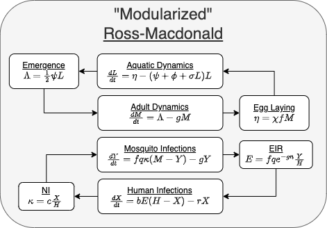

## Generalized

…and finally, we make this a little more abstract. Any model we write to fill one of these roles can be added to the model library and run.

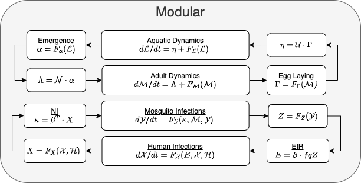

## Setup

To compute a model, we first need to set it up in `exDE.` For the model we started with, the mosquito component is called `RM` and the human component is called `SIS`.

```r
aron_may <- xde_setup("aron_may", MYZname = "RM", Xname = "SIS")
```

The object `aron_may` is a *list* that has a lot of *lists* attached to it, which hold parameter values, initial values, and other information required to run the model. All these can be inspected and changed.

```r
names(aron_may)[c(24,25,26,33,34,35,30,31,32)]
```

```
## [1] "MYZname"  "MYZpar"   "MYZinits" "Xname"    "Xpar"     "Xinits"   "Lname"
## [8] "Lpar"     "Linits"
```

## Solving

This solves the equations and produces a set of orbits. It simulates over 5 years and gives output every 10 days.

```r
aron_may <- xde_solve(aron_may, 5*365, 10)
```

The orbits are attached to `aron_may` and can be inspected as `aron_may$orbits`

```r
names(aron_may$orbits)
```

```
##  [1] "deout"  "time"   "M"      "P"      "Y"      "Z"      "parous" "y"
##  [9] "z"      "H"      "X"      "pr"     "eir"    "ni"     "kappa"  "fqZ"
```

Note that the orbits are parsed and each variable is returned by name. The software computes the EIR and the PR in addition to other terms.

## Plotting

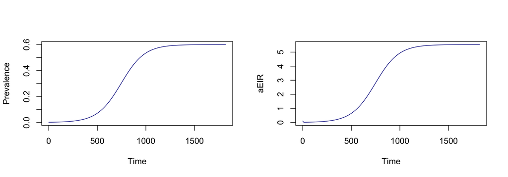

```r
par(mfrow = c(1,2))
with(aron_may$orbits, {
  plot(time, pr, type="l", ylab="Prevalence", xlab="Time", col="darkblue")
  plot(time, 365*eir, type="l", ylab = "aEIR",  xlab="Time", col="darkblue")
})
```

## Modifying a Model

To modify a model, we simply swap out one of its parts. Here, we copy our original and change the emergence function.

```r
aron_may1 = aron_may
aron_may1$Lpar$Lt <- function(t,pars){pars$Lpar$Lambda*(1.01+sin(2*pi*t/365))^3}
aron_may1 <- xde_solve(aron_may1, 5*365, 10)
```

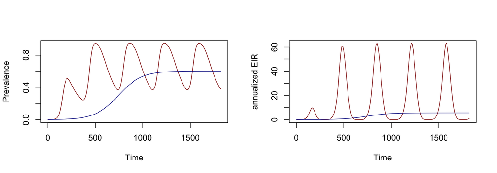

## Asymptotics

One useful built-in function is `xde_stable_orbits` that return the orbits, after they have converged. If the model is not seasonal, the orbit is just the steady state:

```r
aron_may = xde_stable_orbit(aron_may)
aron_may1 = xde_stable_orbit(aron_may1)
```

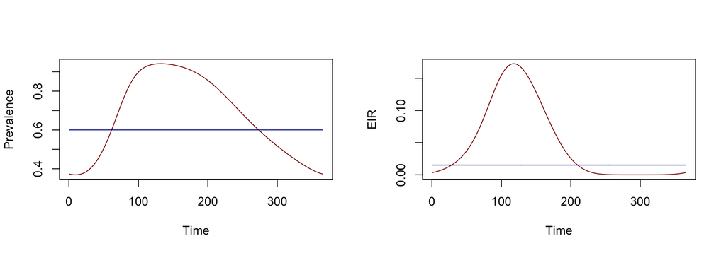

## Scaling Relationships

Another useful function computes the scaling relationship for the average annual EIR, PR, and other terms.

```r
aron_may = xde_scaling(aron_may)
```

Seasonality (dark red) modifies the scaling relationship compared with the non-seasonal model (dark blue)

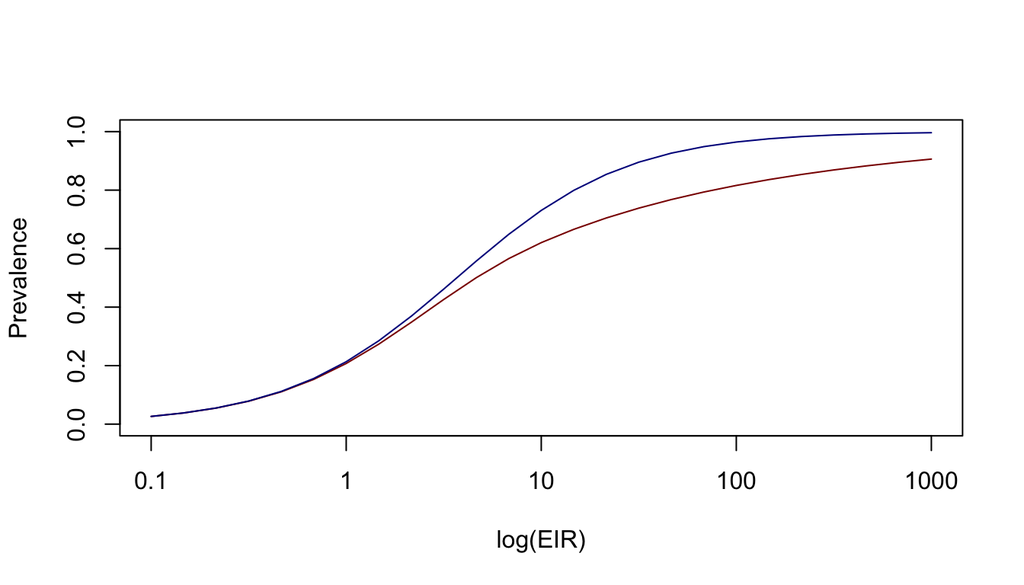

## Calibrating

Using these scaling relationships, it is reasonably easy to calibrate a model. We use `aron_may$eirpr` model to interpolate and return a value that *ought* to be very close to 36% prevalence:

```r
pr2Lambda(.36, aron_may) -> aron_may$Lpar$Lambda
```

```
##   Lambda
## 599.6579
```

```r
aron_may <- xde_stable_orbit(aron_may)
mean(aron_may$steady$pr)
```

```
## [1] 0.3613148
```

It’s not exact, but it’s very close.